# Data Scraping with Python

### ✅Exercise: facility name and facility type

Use the SelectorGadget to identify the tags associated with the **facility name** and **facility type**.

- Facility Name: `tr:nth-child(2) th+ .left:nth-child(2)`
- Facility Type: `tr:nth-child(2) .left~ .left+ td.left`

```python
the_facility_name = webpage.select_one(
    "tr:nth-child(2) th+ .left:nth-child(2)"
).get_text(strip=True)

the_facility_type = webpage.select_one(
    "tr:nth-child(2) .left~ .left+ td.left"
).get_text(strip=True)

print(the_facility_name)
print(the_facility_type)
```

```
Plant 15
Industrial
```

Next, extract all monthly average and maximum daily withdrawal values. Because `.select()` can return multiple elements, a [list comprehension](https://www.w3schools.com/python/python_lists_comprehension.asp) is a natural Python equivalent to `html_nodes(...) |> html_text()`.

```python
avg_nodes = webpage.select(
    ".table:nth-child(7) td:nth-child(7), .table:nth-child(7) td:nth-child(3)"
)

avg_withdrawals = [node.get_text(strip=True) for node in avg_nodes]
avg_withdrawals
```

```
['.584',
 '.492',
 '.647',
 '.613',
 '.543',
 '.683',
 '.371',
 '.650',
 '.349',
 '.535',
 '.447',
 '.449']
```

```python
# Exercise solution: maximum daily withdrawals
max_withdrawals = webpage.select(
    ".table:nth-child(7) td:nth-child(8) , .table:nth-child(7) td:nth-child(4)"
)

max_withdrawals = [node.get_text(strip=True) for node in max_withdrawals]
max_withdrawals
```

```
['1.029',
 '1.045',
 '1.056',
 '1.115',
 '.934',
 '1.096',
 '.978',
 '1.018',
 '1.146',
 '1.046',
 '1.111',
 '.889']
```

## 1.4 Construct a DataFrame and plot the values

The webpage returns the monthly values in a nonchronological order, so we explicitly assign the corresponding month numbers before sorting by date.

```python
month_order = [1, 7, 2, 8, 3, 9, 4, 10, 5, 11, 6, 12]

df_withdrawals = pd.DataFrame({
    "Month": month_order,
    "Year": 2020,
    "Avg_Withdrawals_mgd": pd.to_numeric(avg_withdrawals),
    "Max_Withdrawals_mgd": pd.to_numeric(max_withdrawals),
})

df_withdrawals = df_withdrawals.assign(
    Registrant=the_registrant,
    Facility_name=the_facility_name,
    Facility_type=the_facility_type,
    Date=lambda d: pd.to_datetime(dict(year=d["Year"], month=d["Month"], day=1)),
).sort_values("Date")

df_withdrawals
```

|  | Month | Year | Avg_Withdrawals_mgd | Max_Withdrawals_mgd | Registrant | Facility_name | Facility_type | Date |
| --- | --- | --- | --- | --- | --- | --- | --- | --- |
| 0 | 1 | 2020 | 0.584 | 1.029 | American & Efird, Inc. | Plant 15 | Industrial | 2020-01-01 |
| 2 | 2 | 2020 | 0.647 | 1.056 | American & Efird, Inc. | Plant 15 | Industrial | 2020-02-01 |
| 4 | 3 | 2020 | 0.543 | 0.934 | American & Efird, Inc. | Plant 15 | Industrial | 2020-03-01 |
| 6 | 4 | 2020 | 0.371 | 0.978 | American & Efird, Inc. | Plant 15 | Industrial | 2020-04-01 |
| 8 | 5 | 2020 | 0.349 | 1.146 | American & Efird, Inc. | Plant 15 | Industrial | 2020-05-01 |
| 10 | 6 | 2020 | 0.447 | 1.111 | American & Efird, Inc. | Plant 15 | Industrial | 2020-06-01 |
| 1 | 7 | 2020 | 0.492 | 1.045 | American & Efird, Inc. | Plant 15 | Industrial | 2020-07-01 |
| 3 | 8 | 2020 | 0.613 | 1.115 | American & Efird, Inc. | Plant 15 | Industrial | 2020-08-01 |
| 5 | 9 | 2020 | 0.683 | 1.096 | American & Efird, Inc. | Plant 15 | Industrial | 2020-09-01 |
| 7 | 10 | 2020 | 0.650 | 1.018 | American & Efird, Inc. | Plant 15 | Industrial | 2020-10-01 |
| 9 | 11 | 2020 | 0.535 | 1.046 | American & Efird, Inc. | Plant 15 | Industrial | 2020-11-01 |
| 11 | 12 | 2020 | 0.449 | 0.889 | American & Efird, Inc. | Plant 15 | Industrial | 2020-12-01 |

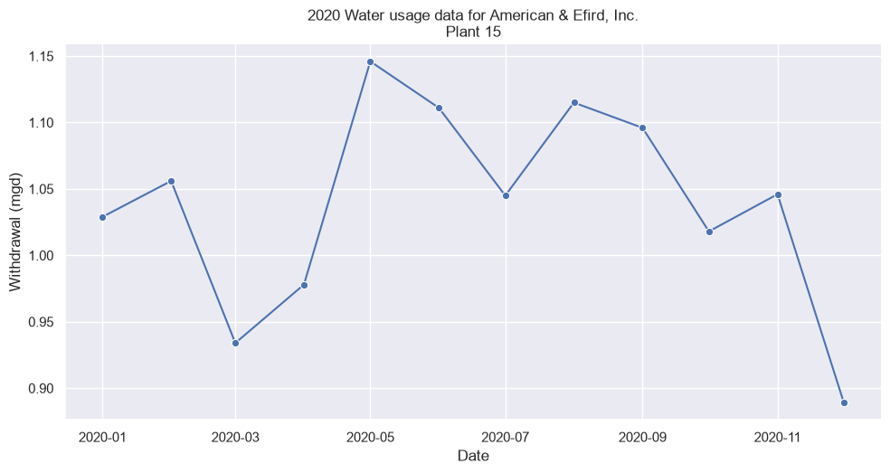

```python
g = sns.relplot(
    data=df_withdrawals,
    x="Date",
    y="Max_Withdrawals_mgd",
    kind="line",
    marker="o",
    aspect=2
)
g.set(
    title=f"2020 Water usage data for {the_registrant}\n{the_facility_name}",
    xlabel="Date",
    ylabel="Withdrawal (mgd)",
);
```

# Part 2. Automating the scraping process

## 2.1 Streamline the process

Move the facility ID, year, URL, and selectors into variables. This makes the workflow easier to reuse before we package it as a function.

```python
#Set variables for the facility ID and the year
the_facility = "0218-0238"
the_year = 2015

#Construct the url using the variables set above
the_base_url = "https://www.ncwater.org/WUDC/app/WWATR/report/view"
the_scrape_url = f"{the_base_url}/{the_facility}/{the_year}"
print(the_scrape_url)

#With the URL set, fetch the web site's contents
response = requests.get(the_scrape_url)
response.raise_for_status()
the_website = BeautifulSoup(response.text, "html.parser")

#The tags remain the same no matter what facility or year you fetch
the_registrant_tag = ".table tr:nth-child(1) td:nth-child(2)"
the_facility_name_tag = "tr:nth-child(2) th+ .left:nth-child(2)"
the_facility_type_tag = "tr:nth-child(2) .left~ .left+ td.left"
the_data_tag = ".table:nth-child(7) td:nth-child(7), .table:nth-child(7) td:nth-child(3)"

#Extract the values from the fetch websites
the_registrant = the_website.select_one(the_registrant_tag).get_text(strip=True)
the_facility_name = the_website.select_one(the_facility_name_tag).get_text(strip=True)
the_facility_type = the_website.select_one(the_facility_type_tag).get_text(strip=True)
the_withdrawals = [x.get_text(strip=True) for x in the_website.select(the_data_tag)]

#Process the values into a dataframe
month_order = [1, 7, 2, 8, 3, 9, 4, 10, 5, 11, 6, 12]
df_withdrawals = pd.DataFrame({
    "Month": month_order,
    "Year": the_year,
    "Avg_Withdrawals_mgd": pd.to_numeric(the_withdrawals),
}).assign(
    Registrant=the_registrant,
    Facility_name=the_facility_name,
    Facility_type=the_facility_type,
)
df_withdrawals["Date"] = pd.to_datetime(
    dict(year=df_withdrawals["Year"], month=df_withdrawals["Month"], day=1)
)
df_withdrawals = df_withdrawals.sort_values("Date")

#Display the results
df_withdrawals.head()
```

```
https://www.ncwater.org/WUDC/app/WWATR/report/view/0218-0238/2015
```

|  | Month | Year | Avg_Withdrawals_mgd | Registrant | Facility_name | Facility_type | Date |
| --- | --- | --- | --- | --- | --- | --- | --- |
| 0 | 1 | 2015 | 0.041 | Aqua North Carolina | Hardscrabble | Public Water Supply | 2015-01-01 |
| 2 | 2 | 2015 | 0.041 | Aqua North Carolina | Hardscrabble | Public Water Supply | 2015-02-01 |
| 4 | 3 | 2015 | 0.041 | Aqua North Carolina | Hardscrabble | Public Water Supply | 2015-03-01 |
| 6 | 4 | 2015 | 0.044 | Aqua North Carolina | Hardscrabble | Public Water Supply | 2015-04-01 |
| 8 | 5 | 2015 | 0.053 | Aqua North Carolina | Hardscrabble | Public Water Supply | 2015-05-01 |

Re-run the workflow with `the_year = 2015`. Then try `facility ID = '0218-0238'`. This demonstrates why parameterizing the workflow is useful.

## 2.2 Automation, Step 1: Build a function

A function lets us provide a year and facility ID and receive a clean DataFrame in return.

```python
def scrape_withdrawals(the_year, the_facility, pause=0):
    """Scrape monthly average withdrawals for one NC facility and year."""
    #Construct the URL and fetch the web page
    url = f"https://www.ncwater.org/WUDC/app/WWATR/report/view/{the_facility}/{the_year}"
    response = requests.get(url)
    response.raise_for_status()
    the_website = BeautifulSoup(response.text, "html.parser")

    #Extract the data from the website object
    registrant = the_website.select_one(".table tr:nth-child(1) td:nth-child(2)").get_text(strip=True)
    facility_name = the_website.select_one("tr:nth-child(2) th+ .left:nth-child(2)").get_text(strip=True)
    facility_type = the_website.select_one("tr:nth-child(2) .left~ .left+ td.left").get_text(strip=True)
    withdrawals = [x.get_text(strip=True) for x in the_website.select(".table:nth-child(7) td:nth-child(7), .table:nth-child(7) td:nth-child(3)")]

    #Wrangle into a dataframe
    month_order = [1, 7, 2, 8, 3, 9, 4, 10, 5, 11, 6, 12]
    df = pd.DataFrame({
        "Month": month_order,
        "Year": the_year,
        "Avg_Withdrawals_mgd": pd.to_numeric(withdrawals),
        "Registrant": registrant,
        "Facility_name": facility_name,
        "Facility_type": facility_type,
    })
    df["Date"] = pd.to_datetime(dict(year=df["Year"], month=df["Month"], day=1))
    df = df.sort_values("Date").reset_index(drop=True)

    #Pause before proceeding
    if pause: time.sleep(pause)

    #Return the dataframe
    return df
```

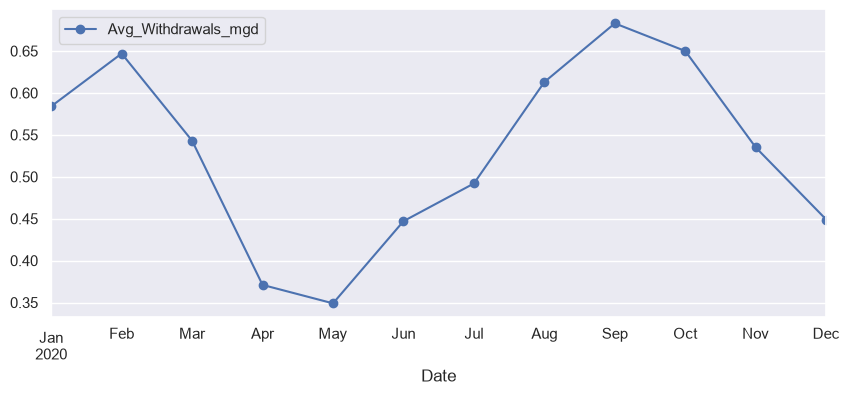

```python
the_df = scrape_withdrawals(2020, "0004-0001")
the_df.plot(kind='line',x='Date',y='Avg_Withdrawals_mgd',figsize=(10,4),marker='o');
```

## 2.3 Iterate across multiple years

Python list comprehensions provide a compact way to repeat a function over a sequence. `pd.concat()` combines the returned DataFrames.

```python
#Set the years we want to scrape, and the facility
the_years = range(2023, 2026)
my_facility = "0004-0001"

#Use list comprehension to capture the result of applying the function to our range of years
the_dfs = [scrape_withdrawals(year, my_facility, pause=1) for year in the_years]

#Combine the resulting dataframes into a single one
the_df = pd.concat(the_dfs, ignore_index=True)
```

```python
the_df.head(10)
```

|  | Month | Year | Avg_Withdrawals_mgd | Registrant | Facility_name | Facility_type | Date |
| --- | --- | --- | --- | --- | --- | --- | --- |
| 0 | 1 | 2023 | 0.542 | American & Efird, Inc. | Plant 15 | Industrial | 2023-01-01 |
| 1 | 2 | 2023 | 0.546 | American & Efird, Inc. | Plant 15 | Industrial | 2023-02-01 |
| 2 | 3 | 2023 | 0.527 | American & Efird, Inc. | Plant 15 | Industrial | 2023-03-01 |
| 3 | 4 | 2023 | 0.493 | American & Efird, Inc. | Plant 15 | Industrial | 2023-04-01 |
| 4 | 5 | 2023 | 0.497 | American & Efird, Inc. | Plant 15 | Industrial | 2023-05-01 |
| 5 | 6 | 2023 | 0.577 | American & Efird, Inc. | Plant 15 | Industrial | 2023-06-01 |
| 6 | 7 | 2023 | 0.569 | American & Efird, Inc. | Plant 15 | Industrial | 2023-07-01 |
| 7 | 8 | 2023 | 0.724 | American & Efird, Inc. | Plant 15 | Industrial | 2023-08-01 |
| 8 | 9 | 2023 | 0.608 | American & Efird, Inc. | Plant 15 | Industrial | 2023-09-01 |
| 9 | 10 | 2023 | 0.572 | American & Efird, Inc. | Plant 15 | Industrial | 2023-10-01 |

Plot the results:

[figure not shown]

```python
#Extract values for plotting
the_registratnt = the_df.loc[0,'Registrant']
the_facility_name = the_df.loc[0,'Facility_name']
start_date = the_df['Date'].min()
end_date = the_df['Date'].max()

#Create the facetgrid
g = sns.relplot(
    data=the_df,
    x="Date",
    y="Avg_Withdrawals_mgd",
    kind="line",
    aspect=3,
    marker='o'
)

#Set the axis labels and the limits of the x-axis
g.set(
    xlabel="Date",
    ylabel="Withdrawal (mgd)",
    #xlim=(start_date, end_date),
    #ylim=(0,the_df['Avg_Withdrawals_mgd'].max()*1.1)
)

#Set titles: "suptitle" is a larger "super" title
g.figure.suptitle(
    f"{the_registrant} - {the_facility_name}",
    fontweight="bold",
    fontsize=14,
    y=1.05 #Place it a bit higher, to make space for the title below
)

#Title is a smaller title
g.ax.set_title(
    f"Water usage data: {start_date.year}-{end_date.year}",
    fontsize=11,
    pad = 2
);
```

# Part 3. Web crawling

Web *crawling* extends scraping across linked pages. Here, the [main report page](https://www.ncwater.org/WUDC/app/WWATR/report) contains links to individual facility reports. We first collect the facility IDs from those links and then apply our scraping function to selected facilities.

## 3.1 Get a list of facility IDs

The R lab selects `#content a`, extracts each link's `href`, splits the path, and takes the facility ID. In Python, we can use `urljoin()` and string methods.

```python
# Fetch the contents of the page listing facilities
the_main_url = "https://www.ncwater.org/WUDC/app/WWATR/report"
response = requests.get(the_main_url)
response.raise_for_status()
the_main_website = BeautifulSoup(response.text, "html.parser")

# Extract the facility ID URLs (href) into a list
links = the_main_website.select("#content a")
hrefs = [link.get("href") for link in links if link.get("href")]

# Extract the facility IDs from the URLs
the_facility_ids = []
for href in hrefs:
    #Split into components
    href_objects = href.split('/')
    #Get the facility ID (2nd last)
    facility_id = href_objects[-2]
    #Append to list
    the_facility_ids.append(facility_id)

#--Or--using list comprehension
the_facility_ids = [href_objects.split('/')[-2] for href_objects in hrefs]

#Show the first 10 items in the list
the_facility_ids[:10]
```

```
['0831-0001',
 '0847-0001',
 '0043-0001',
 '0891-0001',
 '0876-0001',
 '0004-0001',
 '0893-0001',
 '0218-0016',
 '0218-0017',
 '0218-0018']
```